# Text analysis: classification and topic modeling

MACS 30500 University of Chicago

## Supervised learning

1. Hand-code a small set of documents ($N = 1000$)
2. Train a statistical learning model on the hand-coded data
3. Evaluate the effectiveness of the statistical learning model
4. Apply the final model to the remaining set of documents ($N = 1000000$)
- Text classification

## `USCongress`

```
## Classes 'tbl_df', 'tbl' and 'data.frame':    4449 obs. of  6 variables:
##  $ ID      : int  1 2 3 4 5 6 7 8 9 10 ...
##  $ cong    : int  107 107 107 107 107 107 107 107 107 107 ...
##  $ billnum : int  4499 4500 4501 4502 4503 4504 4505 4506 4507 4508 ...
##  $ h_or_sen: Factor w/ 2 levels "HR","S": 1 1 1 1 1 1 1 1 1 1 ...
##  $ major   : int  18 18 18 18 5 21 15 18 18 18 ...
##  $ text    : chr  "To suspend temporarily the duty on Fast Magenta 2 Stage." "To suspend temporarily the duty on Fast Black 286 Stage." "To suspend temporarily the duty on mixtures of Fluazinam." "To reduce temporarily the duty on Prodiamine Technical." ...
```

- Set of hand-coded bills from US Congress
- Text description
- Major policy topic

## Create tidy text data frame

```r
(congress_tokens <- congress %>%
   unnest_tokens(output = word, input = text) %>%
   filter(!str_detect(word, "^[0-9]*$")) %>%
   anti_join(stop_words) %>%
   mutate(word = SnowballC::wordStem(word)))
```

```
## # A tibble: 58,820 x 6
##       ID  cong billnum h_or_sen major        word
##    <int> <int>   <int>   <fctr> <int>       <chr>
##  1     1   107    4499       HR    18     suspend
##  2     1   107    4499       HR    18 temporarili
##  3     1   107    4499       HR    18        duti
##  4     1   107    4499       HR    18        fast
##  5     1   107    4499       HR    18     magenta
##  6     1   107    4499       HR    18       stage
##  7     2   107    4500       HR    18     suspend
##  8     2   107    4500       HR    18 temporarili
##  9     2   107    4500       HR    18        duti
## 10     2   107    4500       HR    18        fast
## # ... with 58,810 more rows
```

## Create document-term matrix

```r
(congress_dtm <- congress_tokens %>%
   count(ID, word) %>%
   cast_dtm(document = ID, term = word, value = n))
```

```
## <<DocumentTermMatrix (documents: 4449, terms: 4902)>>
## Non-/sparse entries: 55033/21753965
## Sparsity           : 100%
## Maximal term length: 24
## Weighting          : term frequency (tf)
```

## Weighting

- Term frequency (tf)
- Term frequency-inverse document frequency (tf-idf)

## Weighting

```r
congress_tokens %>%
  count(ID, word) %>%
  cast_dtm(document = ID, term = word, value = n,
           weighting = tm::weightTfIdf)
```

```
## <<DocumentTermMatrix (documents: 4449, terms: 4902)>>
## Non-/sparse entries: 55033/21753965
## Sparsity           : 100%
## Maximal term length: 24
## Weighting          : term frequency - inverse document frequency (normalized) (tf-idf)
```

## Sparsity

```r
removeSparseTerms(congress_dtm, sparse = .99)
```

```
## <<DocumentTermMatrix (documents: 4449, terms: 209)>>
## Non-/sparse entries: 33794/896047
## Sparsity           : 96%
## Maximal term length: 11
## Weighting          : term frequency (tf)
```

```r
removeSparseTerms(congress_dtm, sparse = .95)
```

```
## <<DocumentTermMatrix (documents: 4449, terms: 28)>>
## Non-/sparse entries: 18447/106125
## Sparsity           : 85%
## Maximal term length: 11
## Weighting          : term frequency (tf)
```

```r
removeSparseTerms(congress_dtm, sparse = .90)
```

```
## <<DocumentTermMatrix (documents: 4449, terms: 16)>>
## Non-/sparse entries: 14917/56267
## Sparsity           : 79%
## Maximal term length: 9
## Weighting          : term frequency (tf)
```

## Exploratory analysis

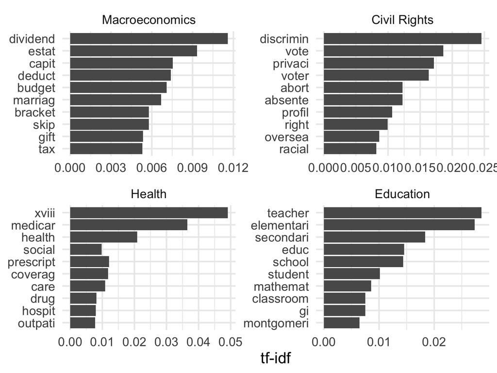

## Estimate model

```r
congress_rf <- train(x = as.matrix(congress_dtm),
                     y = factor(congress$major),
                     method = "rf",
                     ntree = 200,
                     trControl = trainControl(method = "oob"))
```

## Evaluate model

```r
congress_rf_200$finalModel
```

```
##
## Call:
##  randomForest(x = x, y = y, ntree = 200, mtry = param$mtry)
##                Type of random forest: classification
##                      Number of trees: 200
## No. of variables tried at each split: 209
##
##         OOB estimate of  error rate: 34.1%
## Confusion matrix:
##     1  2   3  4   5   6   7   8 10  12 13 14  15  16 17  18 19  20  21 99
## 1  97  0   3  0   3   3   2   5  5  11  1  2  13   3  1   5  0   7   2  0
## 2   1 13   6  1   5   4   4   1  3   6  3  2   8   7  3   1  1  11   4  0
## 3   4  1 532  4  14   9   6   1  4   7  6  2   7  10  1   0  1   5   3  0
## 4   2  1   8 91   4   2   5   1  1   1  0  1   3   0  2   5  1   1   4  0
## 5   5  3  13  2 153  10   4   2 10  13  2  1   7   7  6   7  5   5   6  1
```

[output cut: 36 more lines]

## Evaluate model

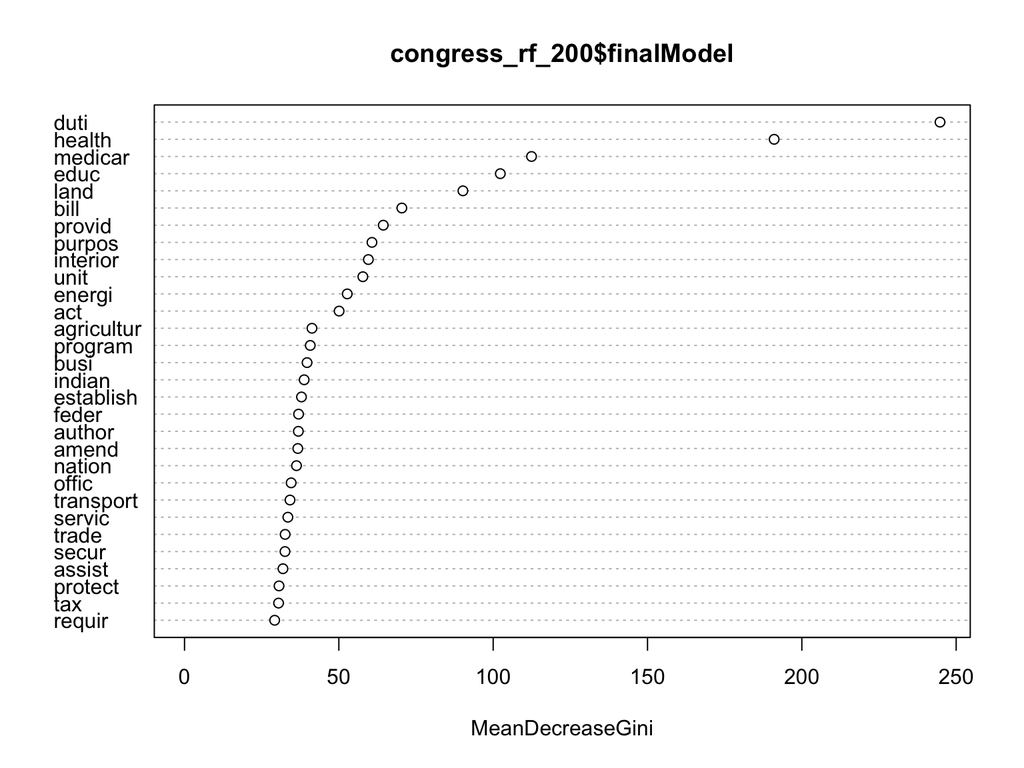

## Topic modeling

- Keywords
- Links
- Themes
- Probabilistic topic models
  - Latent Dirichlet allocation

## Food and animals

1. I ate a banana and spinach smoothie for breakfast.
2. I like to eat broccoli and bananas.
3. Chinchillas and kittens are cute.
4. My sister adopted a kitten yesterday.
5. Look at this cute hamster munching on a piece of broccoli.

## LDA document structure

- Decide on the number of words N the document will have
  - [Dirichlet probability distribution](https://en.wikipedia.org/wiki/Dirichlet_distribution)
  - Fixed set of $k$ topics
- Generate each word in the document:
  - Pick a topic
  - Generate the word
- LDA backtracks from this assumption

## Food and animals

- Decide that $D$ will be 1/2 about food and 1/2 about cute animals.
- Pick 5 to be the number of words in $D$.
- Pick the first word to come from the food topic
- Pick the second word to come from the cute animals topic
- Pick the third word to come from the cute animals topic
- Pick the fourth word to come from the food topic
- Pick the fifth word to come from the food topic

## LDA with a known topic structure

- *Great Expectations* by Charles Dickens
- *The War of the Worlds* by H.G. Wells
- *Twenty Thousand Leagues Under the Sea* by Jules Verne
- *Pride and Prejudice* by Jane Austen

## `topicmodels`

```
## <<DocumentTermMatrix (documents: 193, terms: 18215)>>
## Non-/sparse entries: 104722/3410773
## Sparsity           : 97%
## Maximal term length: 19
## Weighting          : term frequency (tf)
```

## Terms associated with each topic

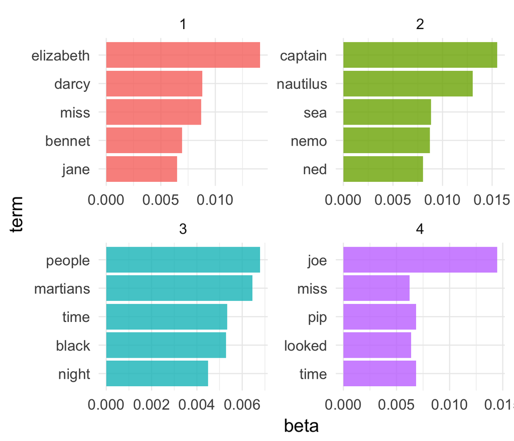

## Per-document classification

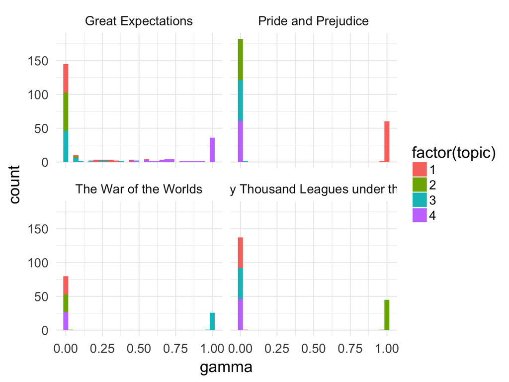

## Consensus topic

```
## # A tibble: 4 x 2
##                               consensus topic
##                                   <chr> <int>
## 1                    Great Expectations     4
## 2                   Pride and Prejudice     1
## 3                 The War of the Worlds     3
## 4 Twenty Thousand Leagues under the Sea     2
```

## Mis-identification

```r
chapter_classifications %>%
  inner_join(book_topics, by = "topic") %>%
  count(title, consensus) %>%
  knitr::kable()
```

| title | consensus | n |
| --- | --- | --- |
| Great Expectations | Great Expectations | 57 |
| Great Expectations | Pride and Prejudice | 1 |
| Great Expectations | The War of the Worlds | 1 |
| Pride and Prejudice | Pride and Prejudice | 61 |
| The War of the Worlds | The War of the Worlds | 27 |
| Twenty Thousand Leagues under the Sea | Twenty Thousand Leagues under the Sea | 46 |

## Incorrectly classified words

| title | Great Expectations | Pride and Prejudice | The War of the Worlds | Twenty Thousand Leagues under the Sea |
| --- | --- | --- | --- | --- |
| Great Expectations | 49656 | 3908 | 1923 | 81 |
| Pride and Prejudice | 1 | 37231 | 6 | 4 |
| The War of the Worlds | 0 | 0 | 22561 | 7 |
| Twenty Thousand Leagues under the Sea | 0 | 5 | 0 | 39629 |

## Most commonly mistaken words

```
## # A tibble: 3,551 x 4
##                 title             consensus     term     n
##                 <chr>                 <chr>    <chr> <dbl>
##  1 Great Expectations   Pride and Prejudice     love    44
##  2 Great Expectations   Pride and Prejudice sergeant    37
##  3 Great Expectations   Pride and Prejudice     lady    32
##  4 Great Expectations   Pride and Prejudice     miss    26
##  5 Great Expectations The War of the Worlds     boat    25
##  6 Great Expectations The War of the Worlds     tide    20
##  7 Great Expectations The War of the Worlds    water    20
##  8 Great Expectations   Pride and Prejudice   father    19
##  9 Great Expectations   Pride and Prejudice     baby    18
## 10 Great Expectations   Pride and Prejudice  flopson    18
## # ... with 3,541 more rows
```

## Associated Press articles

```
## <<DocumentTermMatrix (documents: 2246, terms: 10134)>>
## Non-/sparse entries: 259208/22501756
## Sparsity           : 99%
## Maximal term length: 18
## Weighting          : term frequency (tf)
```

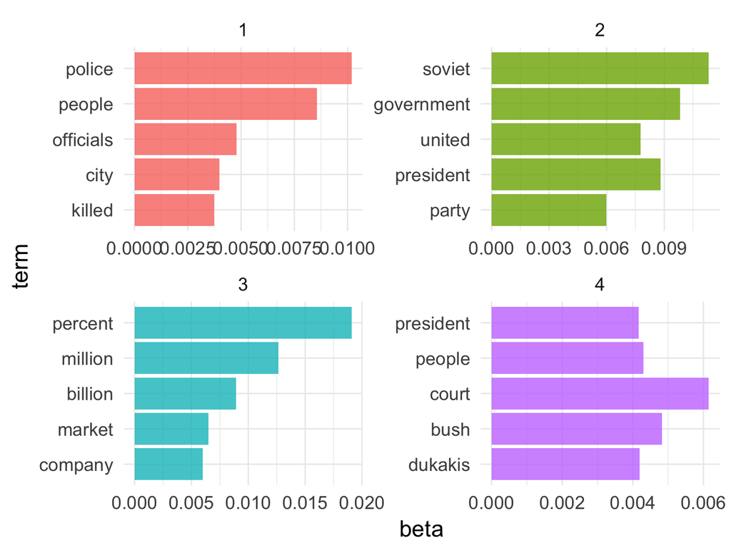

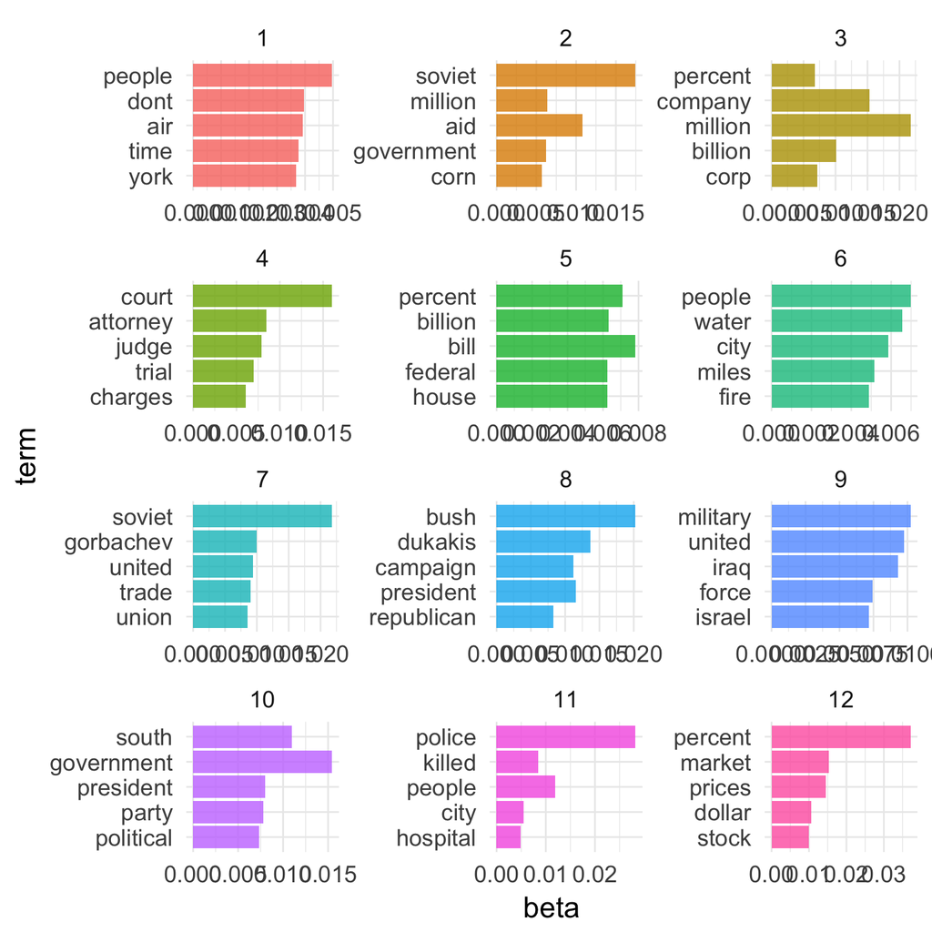

## Perplexity

- A statistical measure of how well a probability model predicts a sample
- Given the theoretical word distributions represented by the topics, compare that to the actual topic mixtures, or distribution of words in your documents
- Perplexity for LDA model with 12 topics
  - 2277.8757156

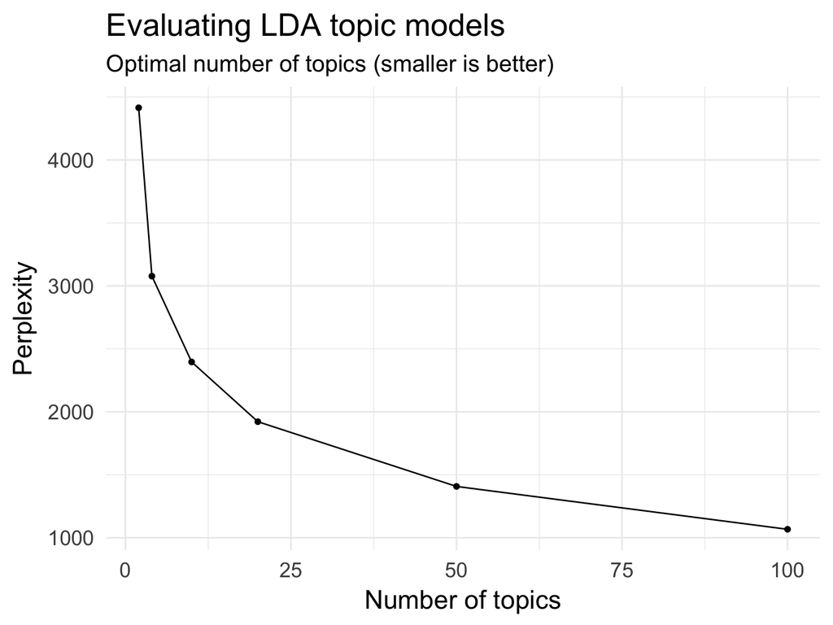

## Topics from $k=100$

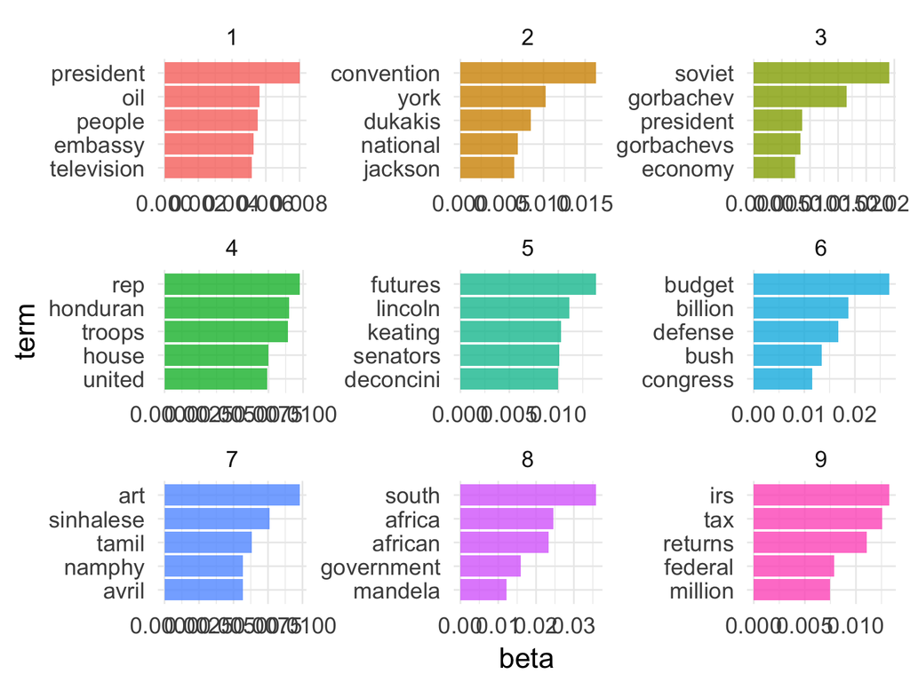